# Text Mining Workflow Example

In this example, I’ll step through some of the steps (on Mac OS X) of getting a collection of texts into R in a tidy format so you can carry out some of the techniques explored in [*Text Mining with R*](https://www.tidytextmining.com/) by Julia Silge and David Robinson.

## From Image or PDFs to Text

The first step is to get your material into a raw text form. If your starting point is a PDF that has no ability to select the text in it (that is, it has not yet been OCRed) then the workflow will be:

1. Install Tesseract. If you don’t already have [homebrew installed](https://brew.sh/) then install it. Then run: `brew install tesseract` from the terminal.
2. If you have a PDF in Preview and export the file to a multi-page TIFF document. If you have a collection of images you can leave them as their respective image format. Note, for higher OCR accuracy, it is very important to pre-process the images of the input file. That can result in far fewer OCR errors when you have a higher contrast, lower noise images. You can do this with image magick, or other image processing software, or even preview, but needs to be done before running tesseract. This would require a tutorial of its own.
3. Run tesseract on the document to OCR it. `tesseract file-name.tiff file-name.txt` This will produce a text file which contains the text, though likely with some proportion of errors.
4. If you have multiple documents, then repeat for each of them
5. If you are working with a single text or number of texts, you can then directly proceed to cleaning up of the PDF using regular expressions in a regex equipped text editor such as Atom. Alternatively you can follow the steps below to process them in R.

If you have already have a PDF with text in it that is selectable, you may either simply select all the text, copy and paste it into an empty text file in, for example, Atom. Or, you may use this alternative:

1. Install pdftotext. If you don’t already have [homebrew installed](https://brew.sh/) then install it. Then run: `brew cask install pdftotext` from the terminal.
2. In the terminal, navigate to the folder that contains only a collection of PDFs with OCRed text in it. To navigate around directories in the terminal you use the `cd` command. To go “up” a directory you enter `cd ..` and to find out what directory you are currently in you can enter `pwd`. To see what is in the current directory you enter `ls` and to ender a directory in the current directory you can enter `cd name-of-directory` or the full path of the directory location in your file hierarchy `cd /home/user/path/to/directory`
3. Once you are in the correct folder, you can convert a single pdf to text by simply entering: `pdftotext name-of-file.pdf` or, if you have a large collection of files you can enter `for file in *.pdf; do pdftotext "$file" "$file.txt"; done` which will convert every PDF in the current directory into text.

## From Text to R

In this example, we’ll work with some volumes (for this example code I’ll just work with #15 and #16) of [Gandhi’s complete works](http://www.gandhiashramsevagram.org/gandhi-literature/collected-works-of-mahatma-gandhi-volume-1-to-98.php).

First we’ll rename the files do that they refer only to the volume number. This will use the `rename` command, which if you don’t have it installed, can be installed with homebrew using `brew install rename`.

`rename 's/.*(\d\d).txt/$1.txt/' *`

Each volume varies in size from just over 600KB to 1.3MB in size.

Let us load some libraries for our use:

```r
library(tidyverse)
library(stringr)
library(tidytext)
```

Now let us import all the volumes (in this example, I’ll only work with volume #15 and #16). We’ll first create an empty variable `mergedlines` and create a `for` loop that cycles through each of the files in the directory containing our text files.

Then we’ll import each file.

```r
mergedlines<-NULL
for(i in list.files("gandhi/"))
{
  importedfile=as_data_frame(list(text=read_lines(paste0("gandhi/",i)),volume=str_replace(i,".txt","")))
  mergedlines<-bind_rows(mergedlines,importedfile)
}
nrow(mergedlines)
```

```
[1] 48092
```

The `read_lines()` command will read our file into a vector of lines of text (I have gotten the location of the file by merging the directory location and the file name of the current imported file i using the `paste0()` command). The `as_data_frame()` command, that creates a tibble, expects a `list` so we give it one consisting of the imported file as text and seperately the volume number, which we have extracted from the file name using `str_replace()`

```r
currentdoc<-NA
mergedlines <- mergedlines %>%
  mutate(document="Unknown")
count<-0
for(i in mergedlines$text)
{
  count<-count+1
  if(str_detect(i,"\\d+\\. [A-Z][A-Z]+"))
  {
    currentdoc<-i
  }
  mergedlines$document[count]<-str_replace(currentdoc,"\f","")
}
```

**NOTE**: This process up to here took 6 seconds for me with a single volume (#15) and 42 seconds with three volumes. If you add all the volumes from vol. 15-97, for example it may take as long as 20-30 minutes to process everything. It is not unusual to have large data sets take a very long time to process.

Now let us break this down into tokens, remove common stop words and look at basic frequencies:

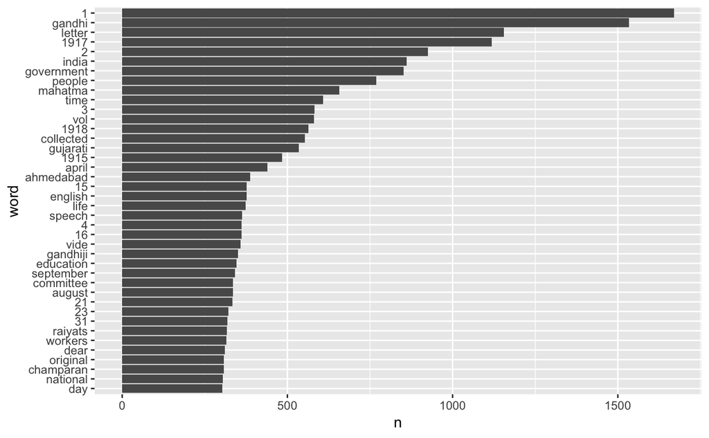

```r
tidy_volumes <- mergedlines %>%
  unnest_tokens(word,text)
data(stop_words) # load the stop words vector
# Remove the stop words from the letter word list using anti_join():
tidy_volumes <- tidy_volumes %>%
  anti_join(stop_words)
# Get the word frequencies:
word_freq <- tidy_volumes %>%
  count(word,sort=TRUE)
head(word_freq,40) %>%
  mutate(word=reorder(word,n)) %>%
  ggplot(aes(word,n)) +
  geom_col() +
  coord_flip()
```

It looks like some numbers might have been worth adding to the stop word list…

```r
my_stop_words <- c("gandhi","letter","1","2","3","4","5","6","7","8","9") # list a few stop words of my own from the letters
my_stop_words_df <- data_frame(word=my_stop_words,lexicon="custom") # prepare to add to custom stop words
stop_words <- stop_words %>% bind_rows(my_stop_words_df) # add the custom stop words to the list
# remove the stop words again:
tidy_volumes <- tidy_volumes %>%
  anti_join(stop_words)
```

What if we wanted only look at word frequencies for letters to one group of recipients?

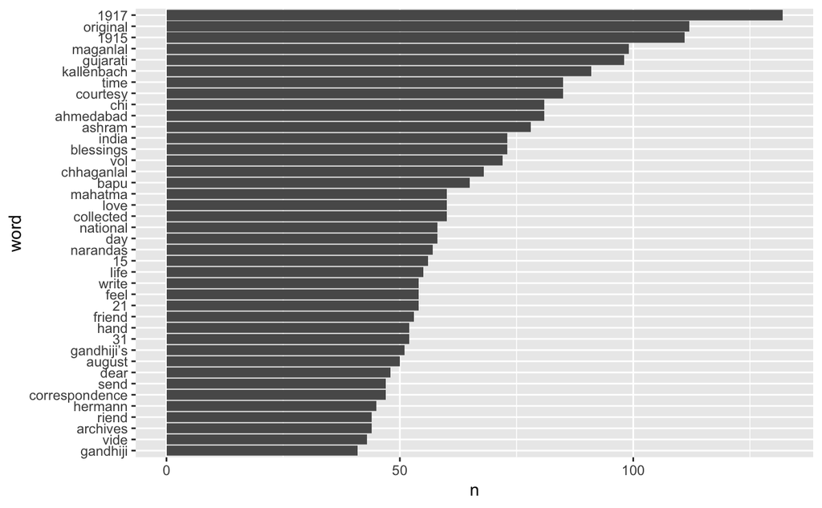

```r
chhaganlal<-tidy_volumes %>%
  filter(str_detect(document,"GANDHI")|str_detect(document,"KALLENBACH")) %>%
  # filters for letter by Chhanganlal, Maganlal, Ramdas, Narandas, Manilal, Khushalchand Gandhi - OR Hermann Kallenbach
  count(word,sort=TRUE)
head(chhaganlal,40) %>%
  mutate(word=reorder(word,n)) %>%
  ggplot(aes(word,n)) +
  geom_col() +
  coord_flip()
```

```r
NA
```

```r
caste<-tidy_volumes %>%
  filter(word=="caste"|word=="castes") %>%
  distinct(document)
caste
```

| document |
| --- |
| 57. LETTER TO KHUSHALCHAND GANDHI |
| 77. LETTER TO HERMANN KALLENBACH |
| 85. LETTER TO MAGANBHAI H. PATEL |
| 102. DIARY FOR 19155 |
| 109. SPEECH AT ARYA SAMAJ FUNCTION, SURAT3 |
| 127. SPEECH ON SWADESHI AT MISSIONARY CONFERENCE, |
| 128. SPEECH ON ‘ASHRAM VOWS’ AT Y. M. C. A., MADRAS1 |
| 141. SPEECH IN REPLY TO ADDRESS, KARACHI |
| 170. SPEECH AT CONFERENCE OF COMMUNITIES |
| 171. SPEECH ON CASTE SYSTEM, AHMEDABAD1 |

[output cut: 9 more lines]

What if we wanted all the lines that mention a particular word?

```r
caste_lines<-mergedlines %>%
  filter(str_detect(text,"caste")) %>%
  select(text, document)
caste_lines
```

| text | document |
| --- | --- |
| banished from the caste and so their sorrow will be a little less. | 57. LETTER TO KHUSHALCHAND GANDHI |
| In which the caste system is accepted as one of the unchanging foundations | 77. LETTER TO HERMANN KALLENBACH |
| I believe in varnashramadharma but I do not believe in castes. | 85. LETTER TO MAGANBHAI H. PATEL |
| Meeting with Patwari. Discussion about caste restrictions. | 102. DIARY FOR 19155 |
| caste affairs are managed; everywhere there is the same story. Parents | 109. SPEECH AT ARYA SAMAJ FUNCTION, SURAT3 |
| organisation of caste answered not only the religious wants of the | 127. SPEECH ON SWADESHI AT MISSIONARY CONFERENCE, |
| \fmanaged their internal affairs through the caste system, and through it | 127. SPEECH ON SWADESHI AT MISSIONARY CONFERENCE, |
| caste system its wonderful power of organisation. One had but to | 127. SPEECH ON SWADESHI AT MISSIONARY CONFERENCE, |
| kitchens that are established in order to serve caste restrictions, but | 128. SPEECH ON ‘ASHRAM VOWS’ AT Y. M. C. A., MADRAS1 |
| brothers of Hindustan without distinction of creed or caste have been | 141. SPEECH IN REPLY TO ADDRESS, KARACHI |

[output cut: 38 more lines]

adding tf_idf:

```r
counts_by_document <- tidy_volumes %>%
  count(document,word,sort=TRUE) %>%
  ungroup()
gandhi_tf_idf <- left_join(tidy_volumes,counts_by_document) %>%
  bind_tf_idf(word,document,n)
gandhi_tf_idf %>%
  arrange(desc(tf_idf)) %>%
  distinct(word,.keep_all=TRUE)
```

| volume | document | word | n | tf | idf | tf_idf |
| --- | --- | --- | --- | --- | --- | --- |
| 16 | 204. FRAGMENT OF LETTER TO MATHURADAS | rebuke | 2 | 0.10526316 | 4.965638 | 0.5226987 |
| 15 | 181. LETTER TO KUNVERJI MEHTA | kunverji | 2 | 0.09090909 | 5.188781 | 0.4717074 |
| 15 | 163. LETTER TO GANGADHARRAO DESHPANDE1 | gangadharrao | 1 | 0.07142857 | 6.575076 | 0.4696483 |
| 15 | 163. LETTER TO GANGADHARRAO DESHPANDE1 | deshpande1 | 1 | 0.07142857 | 6.575076 | 0.4696483 |
| 15 | 163. LETTER TO GANGADHARRAO DESHPANDE1 | majhi | 1 | 0.07142857 | 6.575076 | 0.4696483 |
| 15 | 163. LETTER TO GANGADHARRAO DESHPANDE1 | jivan | 1 | 0.07142857 | 5.881929 | 0.4201378 |
| 15 | 50. LETTER TO MADHURIPRASAD | madhuriprasad | 3 | 0.07894737 | 5.188781 | 0.4096406 |
| 15 | 217. LETTER TO SAM HIGGINBOTTOM | higginbottom | 3 | 0.09090909 | 4.495634 | 0.4086940 |
| 16 | 278. LETTER TO HANUMANTRAO | hanumantrao | 2 | 0.06896552 | 5.881929 | 0.4056503 |
| 15 | 408. LETTER TO JAMNALAL BAJAJ | jamnalal | 2 | 0.08333333 | 4.495634 | 0.3746362 |

[output cut: 990 more lines]